# LRT: integrative analysis of scRNA-seq and TCR-seq data to investigate clonal differentiation heterogeneity

Juan Xie

2023-06-03

# 1 Introduction

This vignette will demonstrate a workflow to investigate clonal differentiation heterogeneity, including preprocessing,overall cell trajectory estimation, clonotype clustering,and clonotype cluster characterization.

# 2 Dataset

We will demonstrate the usage of `LRT` via a real dataset from [Khatun et al](https://pubmed.ncbi.nlm.nih.gov/33201171/).This dataset consists of scTCR-seq data and scRNA-seq data from five mice. The raw data can be accessed at https://www.ncbi.nlm.nih.gov/geo/query/acc.cgi?acc=GSE158896.

# 3 Load packages

```r
## load LRT package
library(LRT)
```

The `LRT` package has multiple dependencies, to use it smoothly, it is advised to install the dependencies before using LRT.

```r
## load dependencies

packages <- c("Seurat", "dplyr", "parallel","tibble", "progress", "DT", "shiny", "shinyBS","shinysky","ggplot2","tidyr")

# Install packages not yet installed
installed_packages <- packages %in% rownames(installed.packages())
if (any(installed_packages == FALSE)) {
  install.packages(packages[!installed_packages])
}
# Packages loading
invisible(lapply(packages, library, character.only = TRUE))

if (!require("BiocManager", quietly = TRUE))
    install.packages("BiocManager")

BiocManager::install("slingshot","SingleCellExperiment","DirichletMultinomial")
```

# 4 Data preprocessing

To begin our analysis of the clonotye lineage, we need to prepare a dataframe containing clonotype information and a seurat object containing cell id, low-dimensional coordinates and clustering labels.

An example R code is provided at https://github.com/JuanXie19/LRT/blob/master/preprocess.r, which illustrates the data pre-processing step and prepares the input for our analysis.

# 5 Combine scTCR-seq and scRNA-seq data

After pre-processing, we need to attach the clonotype information from scTCR-seq to the seurat object.

For the clonotype information,you can choose anything you like, as long as it can be used to define clonotype. Common choices are CDR3 amino acid/nucleotide sequence (prefer paired $\alpha$ $\beta$ chain,although $\alpha$ chain, with two chains separated by ’_‘). Note that the clonotype information must be saved in a column named ’CTaa’ in the scTCR-seq data. If users want to check the V and J gene usage, users should also provide V and J gene information in a column named ‘CTgene’. An example pre-processed seurat object is provided at https://drive.google.com/file/d/17r8WkAIyLmGwaEP4wLHnQkF2nvWDXUPd/view?usp=sharing, and example scTCR-seq data is provided at https://drive.google.com/file/d/1P80GIvhpcZS6ss3m-gf4MwYFJw8UQiKg/view?usp=sharing. Users can download these example data and explore the functions.

To combine scTCR-seq and scRNA-seq data, users can simply call the `getCombinedDataSet` function.

```r
# load TCR data
TCR <-read.csv('/path/to/scTCR-seqData/TCR.csv')

# load seurat object with clustering labels and UMAP coordinates
load('Mice.sub2.rda')

# combine TCR and scRNA-seq
Combined <- getCombinedDataSet(TCR, Mice.sub2)
```

The combined dataset is an updated Seurat object. Users could directly access the object via `@seurat`. They can also easily access the components (seurat cluster labels and TCR sequences) by calling the corresponding accessor functions:

```r
# have a look at the combined dataset
Combined
```

```
#> An object of class "CombinedDataSet"
#> Slot "seurat":
#> An object of class Seurat
#> 45449 features across 7395 samples within 3 assays
#> Active assay: integrated (3000 features, 3000 variable features)
#>  2 other assays present: RNA, SCT
#>  3 dimensional reductions calculated: pca, umap, tsne
```

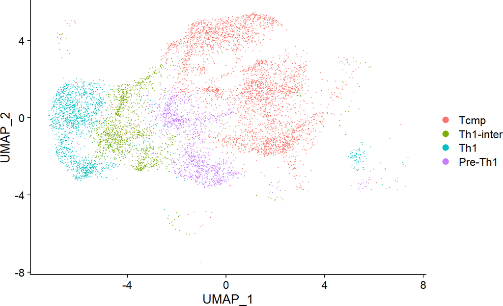

```r
# Visualization--DimPlot
DimPlot(Combined@seurat)
```

```r
# access the cdr3 for first 3 cells
getTCRs(Combined)[1:3]
```

```
#>          M1_AAACCTGCAGTGACAG-1          M1_AAACCTGTCAAAGTAG-1
#>     "CAAEDSNYQLIW_CAWSGRDEQYF" "CAASNNYAQGLTF_CASSDRGPNERLFF"
#>          M1_AAACGGGCACCGAATT-1
#>   "CADTGANTGKLTF_CAWSLVGDTQYF"
```

```r
# access the clustering labels for first 3 cells
seuratClusterLabels(Combined)[1:3]
```

```
#> M1_AAACCTGCAGTGACAG-1 M1_AAACCTGTCAAAGTAG-1 M1_AAACGGGCACCGAATT-1
#>             Th1-inter                   Th1                  Tcmp
#> Levels: Tcmp Th1-inter Th1 Pre-Th1
```

# 6 Exploratory analysis of clonotypes

After combining the data, users can conduct exploratory analysis of the clonotypes by calling `shinyClone` function.

The `shinyClone` will trigger a Shiny app, which consists of two tabs, ‘Clonotype’ and ‘Repertoire’. ‘Clonotype’ shows a table of clonotype, along with the relevant information, e.g., how many cells are associated with each clonotype and how these cells are distributed among cell clusters. If the user clicks a clonotype in this table, they can also check the distribution of cells associated with each clonotype on the UMAP plot. The plot can also be downloaded by clicking the button below the plot.A cell density contour plot is also displayed for clones spanning more than 10 cells.

```r
# explore the distribution of clonotypes
shinyClone(Combined)
```

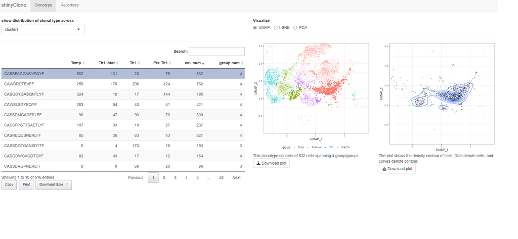

The ‘Repertoire’ tab provides commonly used repertoire analysis functionalities, including clonal diversity, clonal homeostasis, clonal proportion, and clonal overlap analyses.

[figure not shown]

The ‘Repertoire’ tab in shinyClone

# 7 T cell trajectory inference

With the combined data, users can call the `getOverallTrajectory` function to learn the overall cell trajectory. In the backend, the function utilizes the slingshot package for trajectory infernece, thus it inherits the parameters from slingshot. For more information about the parameters, users can refer to related documents provided by slingshot.

```r
Trajectory <- getOverallTrajectory(Combined,start.clus = 'Tcmp')
```

# 8 clonotype clustering

Next,users can call the `shinyClust` to find groups of clonotype with heterogeneous phenotypic distribution along the trajectory. This shiny app allows users to intuitively and dynamically conduct clonotype clustering analysis and clonotype cluster characterization. It consists of four tab, ‘Clustering’, ‘Clonotype cluster exploration’, ‘Biasedness evaluation’ and ‘Clonotype cluster characterization’.

```r
#
shinyClust(Trajectory)
```

The ‘Clustering’ tab allows users to implement clonotype clustering in an interactive manner. A Dirichlet multinomial mixtures (DMM) method is set to be a default here. Users can specify the range for the number of clusters and choose either Laplace, AIC or BIC as a model fit criterion. This page shows a plot of the chosen metric for different numbers of clusters to assist users to determine the optimal number of clusters

[figure not shown]

Clustering tab

On the ‘Clonotype cluster exploration’ tab, upon choosing a particular cluster to display, users can check the distribution of the cells from a specified clonotype cluster along the overall trajectory, as well as the phenotypic distribution of cells for the top-10 expanded clones in the cluster

[figure not shown]

Clonotype cluster exploration tab

On the ‘Bias Evaluation’ tab shows the histogram of pseudotime for each clonotype clusters, along with the permutation test p-values evaluating trajectory biasedness

[figure not shown]

Biasedness evaluation tab

On the ‘Clonotype cluster characterization’ tab, shinyClust updates (i) diversity plot, which shows various diversity indices; and a barplot, which shows the V and J gene usage patterns for the TCR β chain of the clones .

[figure not shown]

Clonotype cluster characterization tab